# CNN_plantSeedling

#### **1. Import the libraries, load dataset, print shape of data, visualize the images in dataset. (5 Marks)**

```python
from google.colab import drive

drive.mount('/content/drive')
```

```python
#Importing necessary libraries
import cv2
import math
import time
import copy

import numpy as np
import pandas as pd
from glob import glob
import seaborn as sns
from matplotlib import pyplot as plt

# tensorflo imports
import tensorflow as tf
from tensorflow.keras import optimizers, losses
from tensorflow.keras.layers import Conv2D, Dropout, MaxPooling2D, Flatten, Activation, BatchNormalization,Dense
from tensorflow.keras.models import Sequential
from tensorflow.math import confusion_matrix
from tensorflow.keras.callbacks import Callback
from tensorflow.keras.preprocessing.image import ImageDataGenerator
from tensorflow.keras.metrics import Recall, Precision
from tensorflow.keras.callbacks import ModelCheckpoint, EarlyStopping
from keras.utils.np_utils import to_categorical # convert to one-hot-encoding
from tensorflow.keras.preprocessing.image import ImageDataGenerator
```

```python
# Set the path to the dataset folder. (The dataset contains image folder: "train")
train_path = "/content/drive/My Drive/Colab Notebooks/data/Plant_seedlings/train.zip"
```

```python
from zipfile import ZipFile
with ZipFile(train_path, 'r') as zip:
  zip.extractall('./df_train')
```

```python
path = "./df_train/*/*.png"                              # The path to all images in training set. (* means include all folders and files.)
files = glob(path)

train_Img = []                                              # Initializing empty list to store the image data as numbers.
train_Label = []                                            # Initializing empty list to store the labels of images
j = 1
num = len(files)

# Obtain images and resizing, obtain labels
for img in files:
    '''
    Appending the image data to train_Img list.
    Appending the labels to train_Label list.
    '''
    print(str(j) + "/" + str(num), end="\r")
    train_Img.append(cv2.resize(cv2.imread(img), (128, 128)))  # Get image (with resizing to 128x128)
    train_Label.append(img.split('/')[-2])  # Get image label (folder name contains the class to which the image belong)
    j += 1

image = np.asarray(train_Img)  # Train images set
labels = pd.DataFrame(train_Label)  # Train labels set
```

```python
print(image.shape)
print(labels.shape)
```

```
(4750, 128, 128, 3)
(4750, 1)
```

```python
print(labels.value_counts())
```

```
Loose Silky-bent             654
Common Chickweed             611
Scentless Mayweed            516
Small-flowered Cranesbill    496
Fat Hen                      475
Charlock                     390
Sugar beet                   385
Cleavers                     287
Black-grass                  263
Shepherds Purse              231
Maize                        221
Common wheat                 221
dtype: int64
```

[figure not shown]

```python
# Image Vizualization (Vizualizing all the 12 category of images)
plt.figure(figsize=(10,10))
for i in range(12):
  plt.subplot(3,4, i+1)
  plt.imshow(image[i], cmap = "gray")
```

#### **2. Data Pre-processing: (15 Marks)**

#### C. Visualize data after preprocessing

Normalization

```python
# Importing asarray from numpy
from numpy import asarray
img2 = asarray(image)

# Confirming image range i.e. 0-255
print("Data Type: %s" % img2.dtype)
print("Min: %.3f, Max: %.3f" % (img2.min(), img2.max()))
```

```
Data Type: uint8
Min: 0.000, Max: 255.000
```

```python
# Converting integers into float
img2 = img2.astype("float32")

# Now normalize it to the range 0-1
img2 /= 255

# After normalization confirming the range again
print("Data Type: %s" % img2.dtype)
print("Min: %.3f, Max: %.3f" % (img2.min(), img2.max()))
```

```
Data Type: float32
Min: 0.000, Max: 1.000
```

Gaussian Blurring

```python
# Let's apply Gaussian blurring method to reduce the unnecessary noise in the image
for idx, img in enumerate(img2):
  img2[idx] = cv2.GaussianBlur(img, (5, 5), 0)
```

Visualize after preprocessing

[figure not shown]

```python
# Visualizing the image after preprocesing the data
plt.figure(figsize=(10,10))
for i in range(12):
  plt.subplot(3,4, i+1)
  plt.imshow(img2[i], cmap = "gray")
```

##### **Observation**

As we can see the above images looked blurred from the original image which helps in further improving the model performance

### **3. Make data compatible: (10 Marks)**

Converting labels to one hot vector

```python
# Converting labels to one hot vectors
from sklearn.preprocessing import OneHotEncoder
from sklearn.preprocessing import LabelBinarizer

encoder = LabelBinarizer()
encoder_label = encoder.fit_transform(labels)
print(encoder_label[0])
```

```
[0 0 0 0 0 0 0 0 0 0 0 1]
```

Splitting the dataset

```python
# Prepare data for the test_train_split
import copy
X = copy.deepcopy(img2)
Y = copy.deepcopy(encoder_label)

# Print the shape
print("X shape: {}".format(X.shape))
print("Y shape: {}".format(Y.shape))
```

```
X shape: (4750, 128, 128, 3)
Y shape: (4750, 12)
```

```python
# import required library
from sklearn.model_selection import train_test_split

# first let's split the data in train and test with 70:30 ratio
X_train, X_test, y_train, y_test = train_test_split(X, Y, test_size = 0.30, random_state = 42, stratify = Y)

# Now splitting the data into validation and test sets with 50:50 ratio
X_val, X_test, y_val, y_test = train_test_split(X_test, y_test, test_size = 0.50, random_state = 42, stratify = y_test)
```

```python
# Printing the shape of all the attributes
print("X_train shape:", X_train.shape)
print("y_train shape:", y_train.shape)
print("X_test shape:", X_test.shape)
print("y_test shape:", y_test.shape)
print("X_val shape:", X_val.shape)
print("y_val shape:", y_val.shape)
```

```
X_train shape: (3325, 128, 128, 3)
y_train shape: (3325, 12)
X_test shape: (713, 128, 128, 3)
y_test shape: (713, 12)
X_val shape: (712, 128, 128, 3)
y_val shape: (712, 12)
```

```python
#Printing the labe for y_train
print(y_train[0])
```

```
[0 0 0 0 0 0 1 0 0 0 0 0]
```

##### Observation

- There are 3325 training images, 713 test images and 712 validation images.
- The size of all the training, testing and valiation image is 128x128x3 and all have 12 number of columns.
- The image size 128x128x3 seems to be good fit for CNN modelling so we d on't need to further reshape the data.

### **4. Building CNN: (15 Marks)**

```python
# Building model using Sequential API
# Max pooling operation for 2D spatial data
# Dropout applies dropout to the input
model = Sequential()
model.add(Conv2D(32, 3, input_shape = X_train.shape[1:], padding = "same", activation = "relu"))
model.add(MaxPooling2D((2,2)))
model.add(Dropout(0.2))
model.add(Conv2D(64, 3, padding = "same", activation = "relu"))
model.add(MaxPooling2D((2,2)))
model.add(Dropout(0.3))
model.add(Conv2D(128, 3, padding = "same", activation = "relu"))
model.add(MaxPooling2D((2,2)))
model.add(Dropout(0.4))
model.add(Conv2D(256, 3,padding = "same",  activation = "relu"))
model.add(MaxPooling2D((2,2)))
model.add(Dropout(0.5))

# Flattening the data for dense network
model.add(Flatten())
model.add(BatchNormalization())

# Now initialize the dense network
model.add(Dense(64, kernel_initializer = "he_normal", use_bias=False))
model.add(BatchNormalization())
model.add(Activation("elu"))
model.add(Dense(32, kernel_initializer = "he_normal", use_bias=False))
model.add(BatchNormalization())
model.add(Activation("elu"))

# Output layer with Softmax function
model.add(Dense(12, activation = "softmax"))

# Optimizers
opt_mzr = optimizers.Adam(learning_rate = 0.001)

model.compile(loss = "categorical_crossentropy", optimizer = opt_mzr, metrics = ["accuracy"])
model.summary()
```

```
Model: "sequential_3"
_________________________________________________________________
Layer (type)                 Output Shape              Param #
=================================================================
conv2d_12 (Conv2D)           (None, 128, 128, 32)      896
_________________________________________________________________
max_pooling2d_12 (MaxPooling (None, 64, 64, 32)        0
_________________________________________________________________
dropout_12 (Dropout)         (None, 64, 64, 32)        0
_________________________________________________________________
conv2d_13 (Conv2D)           (None, 64, 64, 64)        18496
_________________________________________________________________
max_pooling2d_13 (MaxPooling (None, 32, 32, 64)        0
_________________________________________________________________
dropout_13 (Dropout)         (None, 32, 32, 64)        0
_________________________________________________________________
conv2d_14 (Conv2D)           (None, 32, 32, 128)       73856
_________________________________________________________________
max_pooling2d_14 (MaxPooling (None, 16, 16, 128)       0
_________________________________________________________________
dropout_14 (Dropout)         (None, 16, 16, 128)       0
_________________________________________________________________
conv2d_15 (Conv2D)           (None, 16, 16, 256)       295168
_________________________________________________________________
max_pooling2d_15 (MaxPooling (None, 8, 8, 256)         0
_________________________________________________________________
dropout_15 (Dropout)         (None, 8, 8, 256)         0
_________________________________________________________________
flatten_3 (Flatten)          (None, 16384)             0
_________________________________________________________________
batch_normalization_9 (Batch (None, 16384)             65536
_________________________________________________________________
dense_9 (Dense)              (None, 64)                1048576
_________________________________________________________________
batch_normalization_10 (Batc (None, 64)                256
_________________________________________________________________
activation_6 (Activation)    (None, 64)                0
_________________________________________________________________
dense_10 (Dense)             (None, 32)                2048
_________________________________________________________________
batch_normalization_11 (Batc (None, 32)                128
_________________________________________________________________
activation_7 (Activation)    (None, 32)                0
_________________________________________________________________
dense_11 (Dense)             (None, 12)                396
=================================================================
Total params: 1,505,356
Trainable params: 1,472,396
Non-trainable params: 32,960
_________________________________________________________________
```

```python
# Early Stoppping and Model Checkpoint for the Model filt call backs

class EarlyStopping(Callback):
    def __init__(self):
        super(EarlyStopping, self).__init__()
        self.best_weights = None

    def on_train_begin(self, logs=None):
        # The epoch the training stops at.
        self.stopped_epoch = 0

        self.best_val_accuracy = 0.90
        self.best_accuracy = 0.90

    def on_epoch_end(self, epoch, logs=None):
        val_accuracy=logs.get('val_accuracy')
        acc=logs.get('accuracy')

        if np.greater(val_accuracy, self.best_val_accuracy) and np.greater(acc, self.best_accuracy):
            self.best_val_accuracy = val_accuracy
            self.best_accuracy = acc
            self.stopped_epoch = epoch
            self.model.stop_training = True
            self.best_weights = self.model.get_weights()
        else:
            return

    def on_train_end(self, logs=None):
        if self.stopped_epoch > 0:
            print("Epoch %05d: early stopping" % (self.stopped_epoch + 1))
```

```python
# Image Data Generator

generator = ImageDataGenerator(rotation_range=180, width_shift_range=0.10, height_shift_range=0.10, zoom_range=0.15, horizontal_flip=True, vertical_flip=True)
generator.fit(X_train)
itr = generator.flow(X_train, y_train, batch_size=64)
```

### **Fit and evaluate model and print confusion matrix. (10 Marks)**

```python
# Start Model Trainig
start = time.time()
fitt = model.fit(itr, epochs = 60, validation_data = (X_val, y_val), callbacks=[EarlyStopping()], verbose=True)
end = time.time()
print("Total duration: {0}". format(end-start))
```

```
Total duration: 9261.231801509857
```

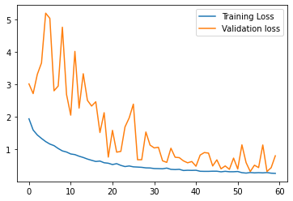

```python
hist = pd.DataFrame(fitt.history)
plt.plot(hist['loss'])
plt.plot(hist['val_loss'])
plt.legend(("Training Loss", "Validation loss"))
```

```python
# Calculating train accuracy, test Accuracy and test loss
score1 = model.evaluate(X_train, y_train, batch_size = 64, verbose = False)
print("Training Accuracy: ", score1[1]*100)
```

```
Training Accuracy:  71.6090202331543
```

```python
score2 = model.evaluate(X_test, y_test, batch_size = 64, verbose = False)
print("Test Accuracy: ", score2[1]*100)
```

```
Test Accuracy:  69.14445757865906
```

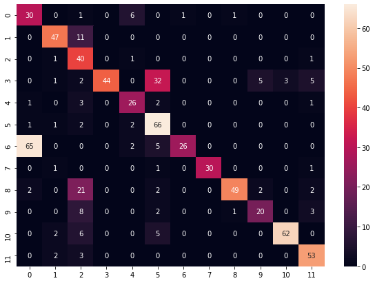

```python
# Get the confusion matrix

y_pred = model.predict(X_test)

y_arr_test = []
y_arr_pred = []

for test in y_test:
  y_arr_test.append(np.argmax(test))

for pred in y_pred:
  y_arr_pred.append(np.argmax(pred))
# Confusion Matrix
cm = confusion_matrix(y_arr_test, y_arr_pred)

df_cm = pd.DataFrame(np.asarray(cm))
plt.figure(figsize = (10,7))
sns.heatmap(df_cm, annot=True, fmt='d')
plt.show()
```

```python
# Calculate Recall and Precision
recall = Recall()
precision = Precision()

recall.update_state(y_test, y_pred)
precision.update_state(y_test, y_pred)

print("Recall: ", recall.result().numpy())
print("Precision: ", precision.result().numpy())
```

```
Recall:  0.65918654
Precision:  0.7389937
```

### **6. Visualize predictions for x_test[2], x_test[3], x_test[33], x_test[36], x_test[59]. (5 Marks)¶**

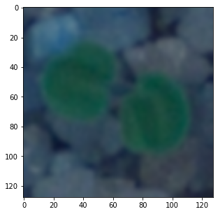

```
[0 0 0 0 0 0 0 0 0 0 1 0]
10
```

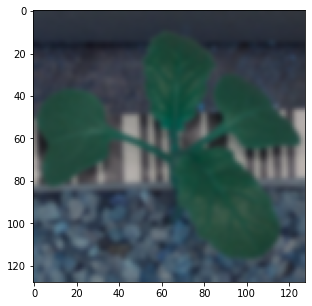

```
[0 1 0 0 0 0 0 0 0 0 0 0]
1
```

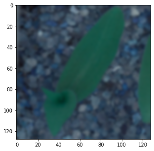

```
[0 0 0 0 0 0 0 1 0 0 0 0]
7
```

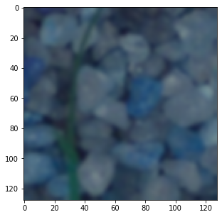

```
[0 0 0 0 0 0 1 0 0 0 0 0]
0
```

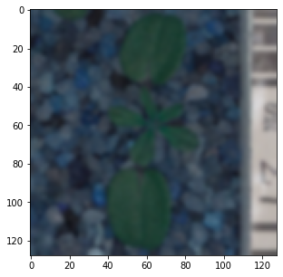

```
[0 0 1 0 0 0 0 0 0 0 0 0]
2
```

```python
## Visualise specific images in the test set

for i in [2,3,33,36,59]:
  X_test[i]
  plt.figure(figsize=(10,5))
  plt.imshow(X_test[i], cmap='gray')
  plt.show()
  print(y_test[i])
  print(y_arr_pred[i])
```